# overview

### kneaddata

Most milk samples have a high proportion of reads removed as *Bos taurus*. Samples 3574, 4448, 4449, and 4450 retain a relatively larger proportion of non-host reads. Sewage samples generally have a low proportion of host reads and retain substantially more reads for downstream microbial analysis.

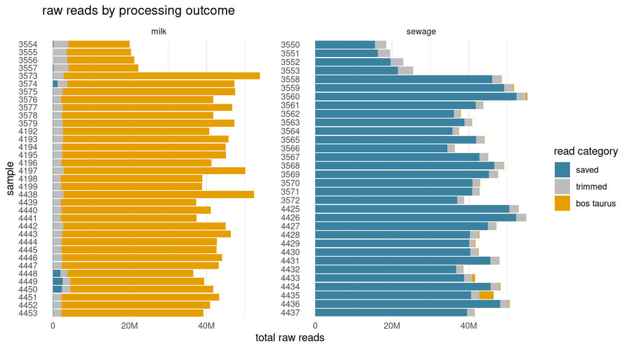

### sourmash

The distance matrices show a clear separation between milk and sewage samples. For angular distance, the median distance is 0.184 among milk samples, 0.822 among sewage samples, and 0.9997 between biomes. This indicates greater similarity among milk samples and higher variability among sewage samples when k-mer abundance is considered.

Jaccard distances are high within both milk and sewage samples (median 0.929 and 0.933, respectively) and nearly maximal between biomes (median 1.000). Since Jaccard ignores abundance, this suggests limited shared k-mer content even among samples from the same biome. These distances summarize sequence similarity and do not directly identify species.

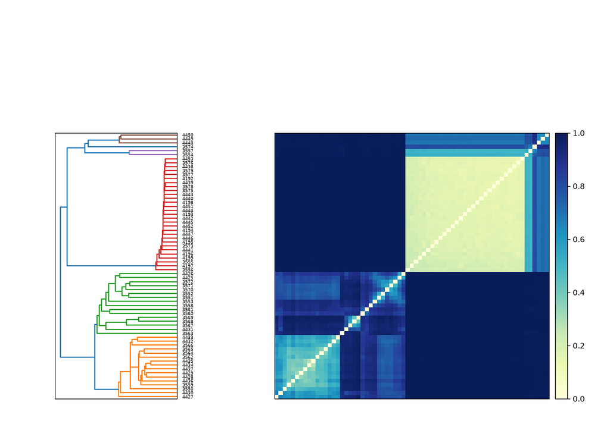

### pipeline overview

Reads are quality-filtered and depleted of *Bos taurus* DNA using KneadData. Genome reconstruction combines single-sample assemblies, multisample binning of concatenated individual assemblies, and coassembly by biome.

Bins are refined with DAS Tool, screened for quality, and dereplicated with dRep to obtain a non-redundant MAG catalogue.

[figure not shown]

Figure 1: Workflow overview showing assembly and binning strategies, MAG catalogue construction, and downstream profiling.

### amr and virulence profiling

AMR genes and virulence factors were quantified using ResFinder and VFDB. FPKM values were recalculated using the number of fragments after trimming but before host DNA removal, to account for differences in host DNA content between samples.

#### antimicrobial resistance

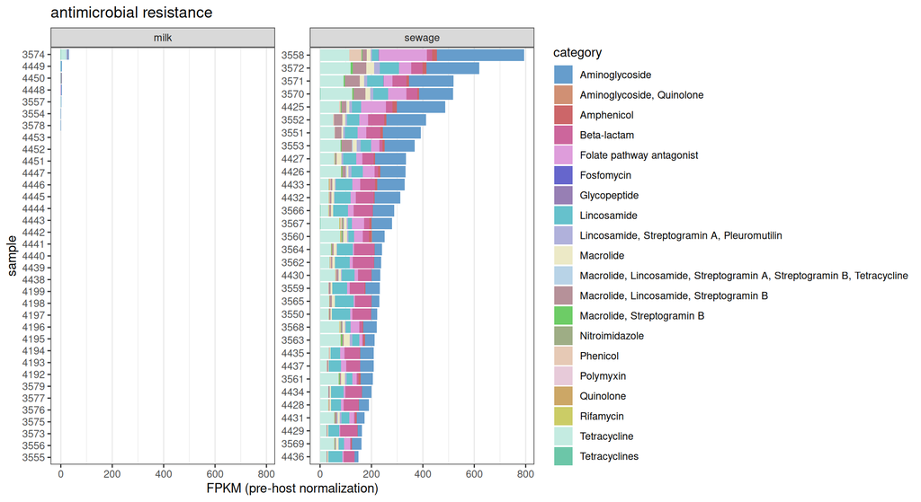

Figure 2: AMR gene abundance by antibiotic class, normalized to pre-host-depletion fragments.

#### virulence factors

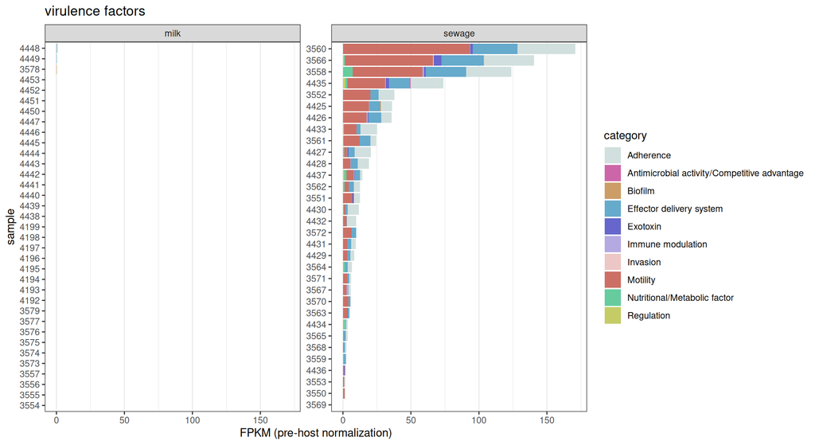

Figure 3: Virulence factor abundance by functional category, normalized to pre-host-depletion fragments.

```
# A tibble: 4 × 4
  database  biome   `=0`  `>0`
  <chr>     <chr>  <int> <int>
1 ResFinder milk      28     7
2 ResFinder sewage     0    32
3 VFDB      milk      32     3
4 VFDB      sewage     0    32
```

### gtdb-tk taxonomy

#### bacteria

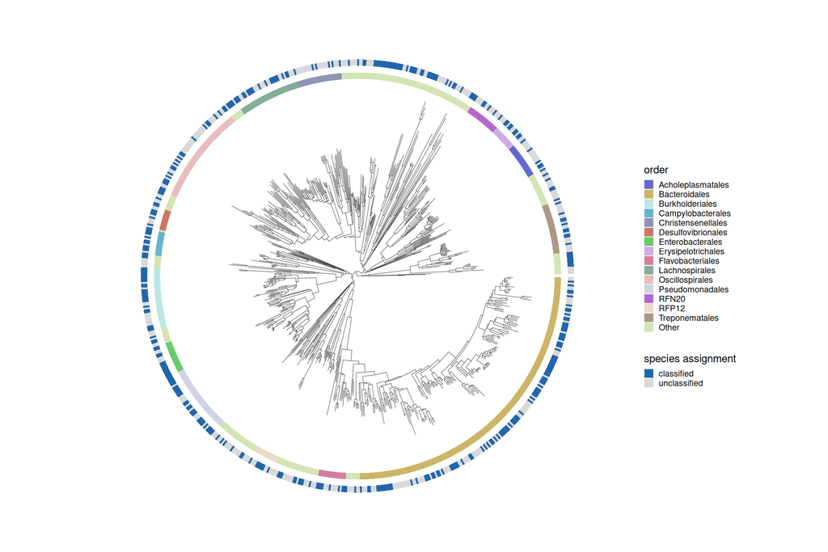

### mags quality

MAG quality was assessed based on genome completeness and contamination. Retained MAGs were classified as high quality (≥90% completeness, ≤5% contamination) or medium quality (≥50% completeness, ≤10% contamination). These categories do not include the additional MIMAG quality criteria.

```
# A tibble: 4 × 5
  domain   quality     n median_completeness median_contamination
  <chr>    <fct>   <int>               <dbl>                <dbl>
1 Archaea  high       12                92.3                 0.52
2 Archaea  medium     12                77.1                 2.49
3 Bacteria high      307                96.3                 1.21
4 Bacteria medium    423                81.9                 3.42
```

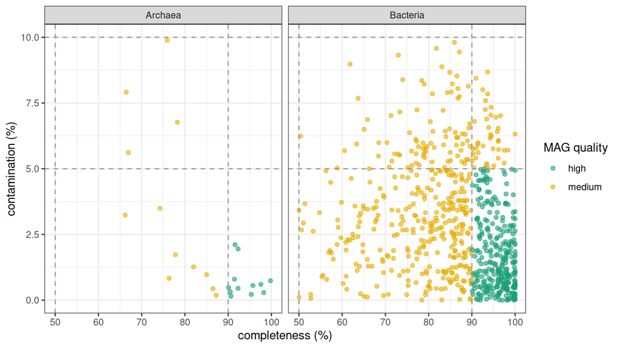

Figure 5: Genome completeness and contamination of reconstructed MAGs.

### mags taxonomic composition

MAG abundances were estimated from CoverM read counts and GTDB-Tk classifications. RPKM values were normalized by genome length and the number of reads before *Bos taurus* removal. Relative abundances were calculated as the fraction of pre-host-depletion reads assigned to each MAG, without rescaling the profiles to 100%.

The 17 most abundant orders across all samples and the two most abundant orders in milk were retained, with remaining orders grouped as Other.

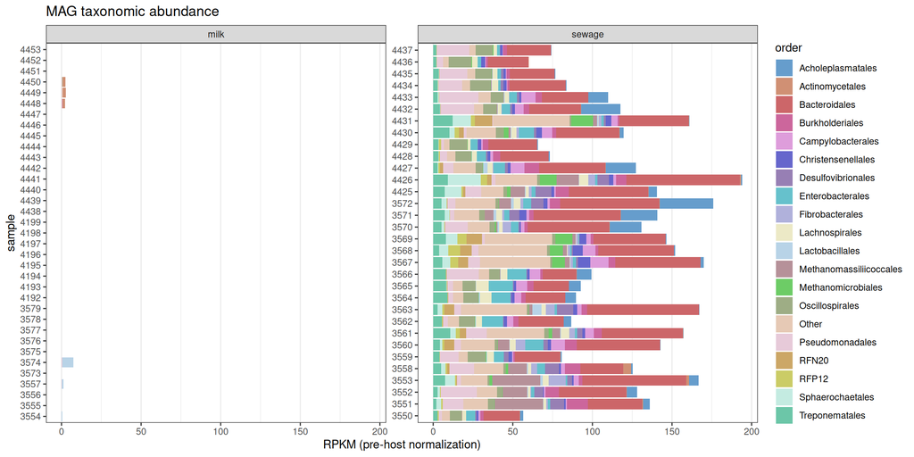

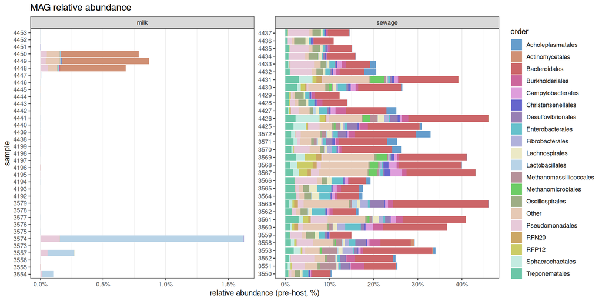

Figure 6: Taxonomic composition of reconstructed MAGs by sample, grouped by GTDB-Tk order.

### mags functional profiling

AMR and virulence-associated genes were screened in reconstructed MAGs using ABRicate with ResFinder and VFDB. Detected genes were linked to GTDB-Tk and NCBI classifications and genome quality estimates. Gene detection does not necessarily indicate pathogenicity.

#### MAGs with detected genes

```
# A tibble: 28 × 10
   mag_id          species ncbi_most_specific quality completeness contamination
   <chr>           <chr>   <chr>              <fct>          <dbl>         <dbl>
 1 3558_SemiBin_42 Aeromo… Aeromonas salmoni… medium          72.7          2.5
 2 3570_SemiBin_2… Psychr… Psychrobacter fae… medium          69.4          1.47
 3 3574_SemiBin_3  Lactoc… Lactococcus cremo… high            99.9          0.24
 4 4425_COMEBin_3… UBA105… Bacteroidales      high            98.2          1
 5 4426_COMEBin_5… Phocae… Phocaeicola pauro… high            93.7          0.44
 6 sewage_COMEBin… Flavob… Myroides           medium          86.5          8.53
 7 sewage_SemiBin… <NA>    Tissierella        medium          88.2          0.37
 8 3553_COMEBin_1… <NA>    Candidatus Cloaci… high            99.0          2.24
 9 3558_SemiBin_80 <NA>    Flavobacterium     high            97.1          3.15
10 3559_SemiBin_6  Marino… Halomonadaceae     medium          89.3          1.93
# ℹ 18 more rows
# ℹ 4 more variables: n_genes_AMR <int>, genes_AMR <chr>, n_genes_VFDB <int>,
#   genes_VFDB <chr>
```

#### AMR and virulence gene distribution

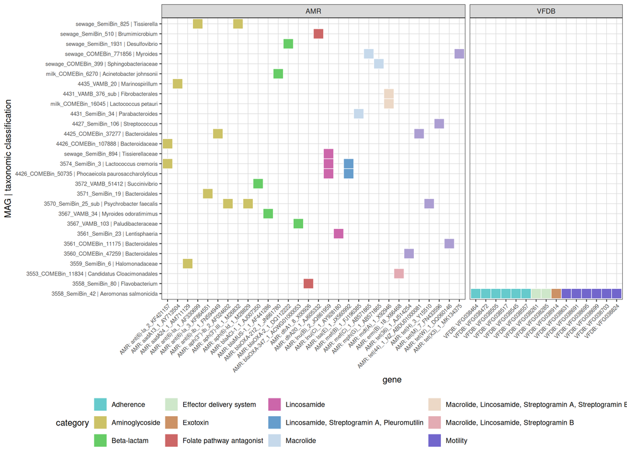

Figure 7: Distribution of AMR and virulence-associated genes across reconstructed MAGs. Colors indicate functional categories; MAG labels include the most specific available taxonomic classification.